# Acceso y uso de World Bank Data mediante WDI

Dereck Amesquita - DAEC Consultoría

Agosto - 2022

## Resumen

Se iniciara con la descarga de series mediante WDI, posteriormente se enseñara como guardar la data en CSV por si existiera la necesidad. Los primeros gráficos seran expuestos usando el indicador de la inflación. El uso de WDIsearch sera clave para entender como encontrar los códigos de los indicadores que necesitamos. Finalmente buscaremos una serie sobre la esperanza de vida, en la cual haremos un conjunto de tratamiento de datos y de gráficos.

# Motivación

En este segundo documento de la línea de R y RStudio, se brindará una guía clara sobre el uso de la librería WDI, con la cual podremos acceder a la data oficial del banco mundial. La demanda de datos estadísticos de buena calidad sigue aumentando. Las estadísticas oportunas y confiables son insumos clave para la amplia estrategia de desarrollo. Las mejoras en la calidad y cantidad de datos sobre todos los aspectos del desarrollo son esenciales si queremos lograr el objetivo de un mundo sin pobreza.

## ¿Por qué usar R en vez del clásico Excel?

Comúnmente podemos descargar esta data de la web del Banco Mundial, pero esto es algo tardado y se complica si queremos usar distintos indicadores para varios países. Veremos que mediante R, este trabajo se vuelve casi automático.

# Sobre la base de datos

En el Banco Mundial, el Grupo de Datos de Desarrollo coordina el trabajo estadístico y de datos y mantiene una serie de bases de datos macro, financieras y sectoriales. Al trabajar en estrecha colaboración con las regiones del Banco y las prácticas globales, el grupo se guía por estándares profesionales en la recopilación, compilación y difusión de datos para garantizar que todos los usuarios de datos puedan tener confianza en la calidad e integridad de los datos producidos. Conoce más en “https://data.worldbank.org/about”.

Librerías necesarias :

```r
library(tidyverse)
library(WDI)
library(ggplot2)
library(dplyr)
```

*Recuerda que si no tienes instaladas estas librerias deberas usar, por ejemplo: install.packages(“WDI”)*

La demanda de datos estadísticos de buena calidad sigue aumentando. Las estadísticas oportunas y confiables son insumos clave para la amplia estrategia de desarrollo. Las mejoras en la calidad y cantidad de datos sobre todos los aspectos del desarrollo son esenciales si queremos lograr el objetivo de un mundo sin pobreza.

# Explorando el potencial de WDI

Asumiremos que ya conocemos los indicadores que necesitamos, en este caso usaremos los siguientes:

- NY.GDP.PCAP.KD.ZG - GDP per capita growth (annual %)
- FP.CPI.TOTL.ZG - Inflation, consumer prices (annual %)

## Descarga la data

Creando la variable “datawdi”, obtendremos mediante la función WDI los datos que especifiquemos. En primer lugar, country, en donde podemos crear un vector con las abreviaciones de cada país que necesitemos. Para encontrar la lista de abreciaciones podemos ayudarnos de *“https://wits.worldbank.org/wits/wits/witshelp/content/codes/country_codes.htm”*. Si quisiéramos la data de todos los países disponibles podríamos usar “all”, en un ejemplo posterior lo veremos. Ahora pasamos a mencionar los indicadores, igual que el anterior, podemos usar un vector, en este caso colocaremos los mencionados anteriormente, si quieres la lista de indicadores tienes 2 opciones, podrías entrar a la web *https://data.worldbank.org/indicator* y ver que cada indicador tiene su código en la URL, la segunda opción y la más profesional es usar WDIsearch, lo cual veremos más adelante.

Tanto “start” como “end” serán usados para establecer las fechas, en el caso de usar una fecha con la que no se cuenten con datos, WDI nos devolverá solo hasta donde se hayan sistematizado dichos datos, es decir, si podemos 2025, nuestra descarga de datos llegará hasta 2021 y no se crearan valores ausentes. Finalmente, language = “es” hará que nos brinde los títulos de los indicadores en español, si no especificamos esto, será en inglés.

```r
datawdi = WDI(
  country = c("PER","CHL","COL","BRA"),
  indicator = c("NY.GDP.PCAP.KD.ZG","FP.CPI.TOTL.ZG"),
  start = 1980,
  end = 2025,
  language = "es" #Labels en Español
)

str(datawdi)
```

```
'data.frame':   168 obs. of  5 variables:
 $ iso2c            : chr  "BR" "BR" "BR" "BR" ...
 $ country          : chr  "Brasil" "Brasil" "Brasil" "Brasil" ...
 $ year             : int  1980 1981 1982 1983 1984 1985 1986 1987 1988 1989 ...
 $ NY.GDP.PCAP.KD.ZG: num  6.65 -6.48 -1.5 -5.14 3.06 ...
  ..- attr(*, "label")= chr "Crecimiento del PIB per cápita (% anual)"
 $ FP.CPI.TOTL.ZG   : num  NA 102 101 135 192 ...
  ..- attr(*, "label")= chr "Inflación, precios al consumidor (% anual)"
```

```r
head(datawdi)
```

|  | iso2c | country | year | NY.GDP.PCAP.KD.ZG | FP.CPI.TOTL.ZG |
| --- | --- | --- | --- | --- | --- |
| 1 | BR | Brasil | 1980 | 6.652537 | NA |
| 2 | BR | Brasil | 1981 | -6.478748 | 101.7251 |
| 3 | BR | Brasil | 1982 | -1.503863 | 100.5434 |
| 4 | BR | Brasil | 1983 | -5.142491 | 135.0277 |
| 5 | BR | Brasil | 1984 | 3.063433 | 192.1217 |
| 6 | BR | Brasil | 1985 | 5.545479 | 225.9897 |

```r
tail(datawdi)
```

|  | iso2c | country | year | NY.GDP.PCAP.KD.ZG | FP.CPI.TOTL.ZG |
| --- | --- | --- | --- | --- | --- |
| 163 | PE | Perú | 2016 | 2.4229049 | 3.557177 |
| 164 | PE | Perú | 2017 | 0.8291263 | 2.994900 |
| 165 | PE | Perú | 2018 | 2.1981396 | 1.509154 |
| 166 | PE | Perú | 2019 | 0.6015437 | 2.252122 |
| 167 | PE | Perú | 2020 | -12.1987620 | 2.002412 |
| 168 | PE | Perú | 2021 | 12.0326134 | 4.271664 |

### Renombrar los colnames o los títulos de columnas

Para realizar esta tarea, con fines de práctica, he cambiado los títulos con 3 formas distintas, puedes realizar la que mejor te parezca.

```r
names(datawdi)[names(datawdi)=='year'] <- 'Año'
datawdi = datawdi %>% rename (País = country)
datawdi = rename (datawdi, PBIperCapita = NY.GDP.PCAP.KD.ZG)
names(datawdi)[names(datawdi)=='FP.CPI.TOTL.ZG'] <- 'Inflación'
```

## Guardar la data en formato CSV

Bastante sencillo si lo que necesitas es llevarte la data a otro lugar, bastará con especificar el DataFrame, en este caso es “datawdi” y posteriormente se le asigna una ubicación.

```r
write.csv(datawdi, file="datawdi.csv")
```

## Primeros gráficos

Ahora crearemos unas capas de que le daran cierto estilo a nuestros gráficos con ggplot. Esto lo hago con el fin de no agregar los codigos extensos de los estilos a cada gráfico.

```r
ubi =  theme(plot.title = element_text (hjust = 0.5 ), plot.subtitle = element_text (hjust = 0.5 ),  plot.caption.position = "plot", plot.caption = element_text(hjust = 0))
tit =  labs(caption = "Elaborado por Dereck Amesquita en RStudio")
```

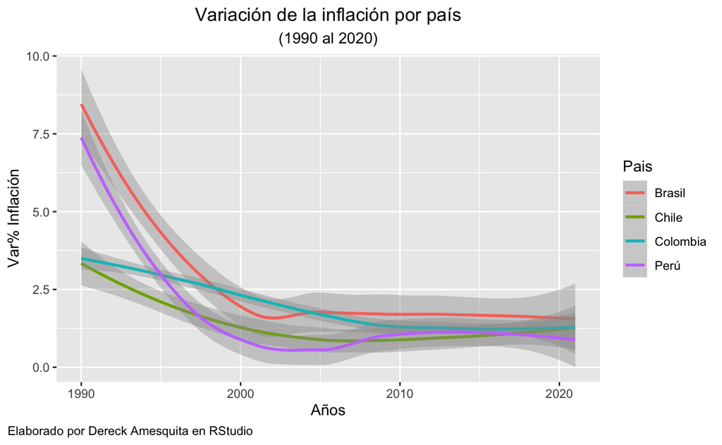

```r
grafico1 = ggplot(datawdi, aes(x=Año, y=log(Inflación), color=País)) +geom_smooth() +
   scale_x_continuous(limits = c(1990,2021)) + labs(x="Años", y="Var% Inflación", colour= "Pais", title = "Variación de la inflación por país", subtitle = "(1990 al 2020)")
grafico1 + ubi + tit # Llamamos a los estilos definidos anteriormente
```

```r
NA
```

En el caso que quisieramos recortar el número de años podemos hacerlo con “scale_x_continuous”..

```r
grafico2 = ggplot(datawdi, aes(Año, log(Inflación), color=País)) +
  geom_smooth() + scale_x_continuous(limits = c(2010,2021)) +
  labs(x="Años",
       y="Var% Inflación",
       colour= "Pais",
       title = "Variación de la inflación por país",
       subtitle = "(De 2010 al 2020)")

grafico2 + ubi + tit # Llamamos a los estilos definidos anteriormente
```

[output not shown]

# Busqueda de series mediante WDIsearch

Este es el segundo punto más importante, puesto que el Banco Mundial tiene una inmensa cantidad de indicadores y muchas veces podemos perdernos en ello. Usaremos la función “WDIsearch”, mediante string especificaremos alguna palabra clave para encontrar nuestro indicador. Por ejemplo, pondremos “GDP”, es importante resaltar que no hay un buscador en español, y las palabras que usemos tienen que estar en inglés.

```r
firstfind = WDIsearch(string='GDP', field='indicator', cache=NULL)
dim(firstfind)
```

```
[1] 166   2
```

```r
head(firstfind)
```

```
     indicator            name
[1,] "5.51.01.10.gdp"     "Per capita GDP growth"
[2,] "6.0.GDP_current"    "GDP (current $)"
[3,] "6.0.GDP_growth"     "GDP growth (annual %)"
[4,] "6.0.GDP_usd"        "GDP (constant 2005 $)"
[5,] "6.0.GDPpc_constant" "GDP per capita, PPP (constant 2011 international $) "
[6,] "BN.CAB.XOKA.GDP.ZS" "Current account balance (% of GDP)"
```

La función dim nos indica que se tienen 166 observaciones y 2 columnas. Con head podemos ver los 6 primeros resultados. Ahora podemos conocer que indicador se ajusta mas a lo que buscamos.

## Aplicaciones con la esperanza de vida

Buscaremos “life expectancy at birth”.

```r
WDIsearch(string='life expectancy at birth')
```

```
     indicator           name
[1,] "SP.DYN.LE00.FE.IN" "Life expectancy at birth, female (years)"
[2,] "SP.DYN.LE00.IN"    "Life expectancy at birth, total (years)"
[3,] "SP.DYN.LE00.MA.IN" "Life expectancy at birth, male (years)"
[4,] "SP.DYN.LIFE.MF"    "Life Expectancy at Birth(years)"
```

```r
data = WDI(
  country = "all",
  indicator = "SP.DYN.LE00.IN",
  start = 2000,
  end = 2025,
  language = "es" #Labels en Español
)
dim(data)
```

```
[1] 5852    4
```

### Tratamiento de datos

Primero, borraremos todos los datos ausentes. Esto no necesariamente es lo óptimo, pero el objetivo de este documento es el uso de WDI, asi que no es del todo necesario centrarnos en el tratamiento de datos.

Crearemos un nuevo DataFrame llamado “esperanza”, el cual sera una agrupación por año de los datos descargados, donde se promediaria la esperanza de vida al nacer. Es decir tendremos una tabla donde esten los años y el promedio de la esperanza de vida de todos los paises.

```r
data = na.omit(data)
esperanza = data %>%
  group_by(year) %>%
  summarise(promvida = mean(SP.DYN.LE00.IN))
esperanza
```

| year | promvida |
| --- | --- |
| 2000 | 66.62905 |
| 2001 | 66.91887 |
| 2002 | 67.26790 |
| 2003 | 67.45870 |
| 2004 | 67.83849 |
| 2005 | 68.14353 |
| 2006 | 68.53713 |
| 2007 | 68.92113 |
| 2008 | 69.30790 |
| 2009 | 69.70370 |

[output cut: 11 more lines]

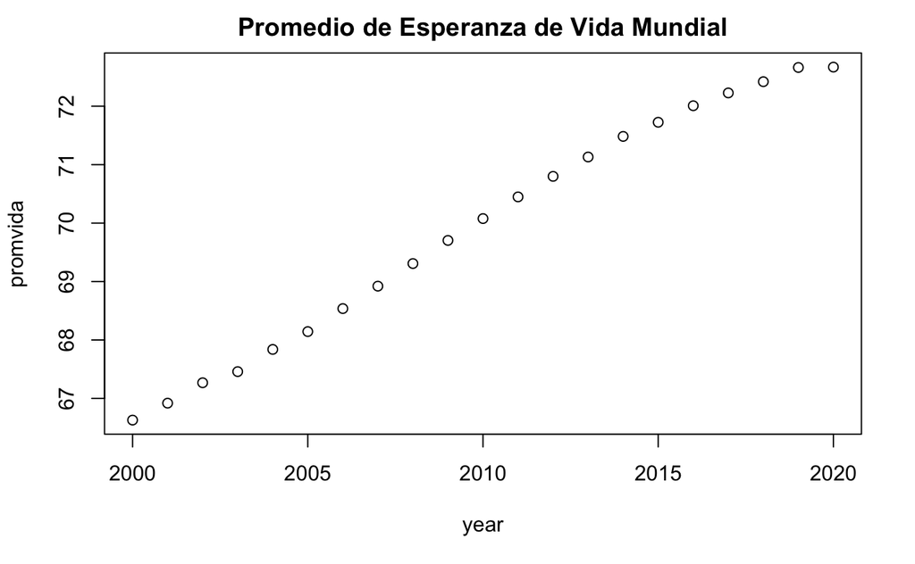

```r
plot(esperanza, main = "Promedio de Esperanza de Vida Mundial")
```

### Paises con esperanza de vida mayor a 80 años

Filtraremos dentro de data, pero primero vamos a agrupar a todos por paises y ya no años. Entonces calcularemos la media de la esperanza de vida para cada pais a lo largo de los años. Posteriormente filtraremos los que sean mayores e igual a 80, por último usamos arrange para ordenarlos.

```r
esp_coun = data %>%
  group_by(country) %>%
  summarise(promvida = mean(SP.DYN.LE00.IN)) %>%
  filter(promvida >=80) %>%
  arrange(desc(promvida))
esp_coun
```

| country | promvida |
| --- | --- |
| Hong Kong, Región Administrativa Especial | 83.08084 |
| Japón | 82.88720 |
| Región Administrativa Especial de Macao, China | 82.58262 |
| Islas Caimán | 82.19024 |
| Suiza | 82.13426 |
| Islandia | 81.84774 |
| Italia | 81.79454 |
| España | 81.60894 |
| Liechtenstein | 81.55180 |
| Australia | 81.52056 |

[output cut: 18 more lines]

### Gráficos con ggplot

```r
esperanza
```

| year | promvida |
| --- | --- |
| 2000 | 66.62905 |
| 2001 | 66.91887 |
| 2002 | 67.26790 |
| 2003 | 67.45870 |
| 2004 | 67.83849 |
| 2005 | 68.14353 |
| 2006 | 68.53713 |
| 2007 | 68.92113 |
| 2008 | 69.30790 |
| 2009 | 69.70370 |

[output cut: 11 more lines]

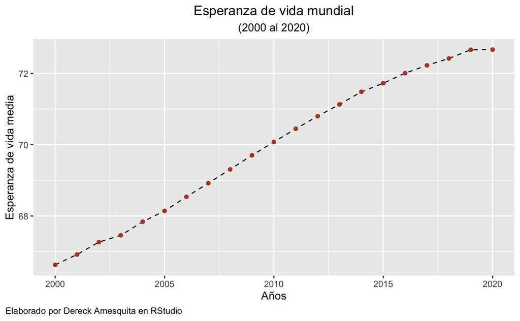

```r
grafico3 <- ggplot(data = esperanza, aes(x=year, y=promvida)) +geom_line(linetype = "dashed")+
  geom_point(color = "#B6472F") + labs (x="Años" , y ="Esperanza de vida media", title = "Esperanza de vida mundial", subtitle = "(2000 al 2020)")
grafico3 + ubi + tit
```

### Esperanza de vida en Sudamérica

Especificamos los paises.

```r
data = WDI(
  country = c("PER","CHL","COL","BRA", "ARG","BOL","ECU","COL"),
  indicator = c("SP.DYN.LE00.IN"),
  start = 1980,
  end = 2025,
  language = "es" #Labels en Español
)
```

Ahora repetimos el proceso para omitir datos y creamos el ggplot. Este es muy similar a los anteriores.

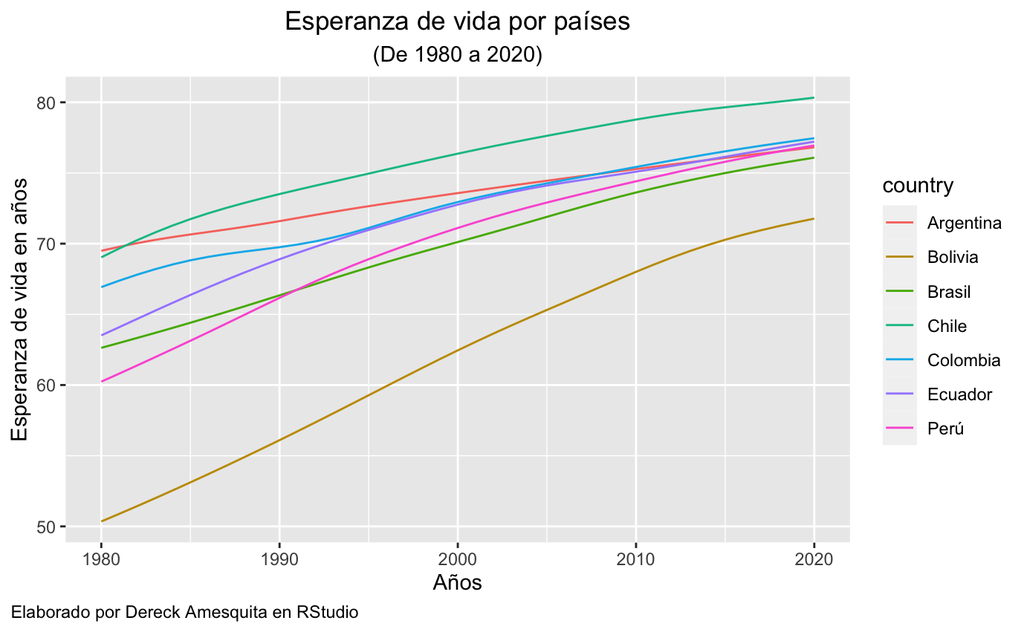

```r
data = na.omit(data)

grafico4 <- ggplot(data, aes(x=year,y=SP.DYN.LE00.IN, color=country)) + geom_line() +
  labs(x="Años", y = "Esperanza de vida en años",
       title = "Esperanza de vida por países",
       subtitle = "(De 1980 a 2020)")
grafico4 + ubi + tit
```

En este caso vamos a hacer un ggplot, con una tabla nueva. Agrupamos la data por paises y le calculamos el promedio, el cual sería por años.

```r
esperanza = data %>%
  group_by(country) %>%
  summarise(promvida = mean(SP.DYN.LE00.IN))
esperanza
```

| country | promvida |
| --- | --- |
| Argentina | 73.42856 |
| Bolivia | 61.94146 |
| Brasil | 69.87534 |
| Chile | 75.90666 |
| Colombia | 72.63429 |
| Ecuador | 71.82100 |
| Perú | 70.10676 |

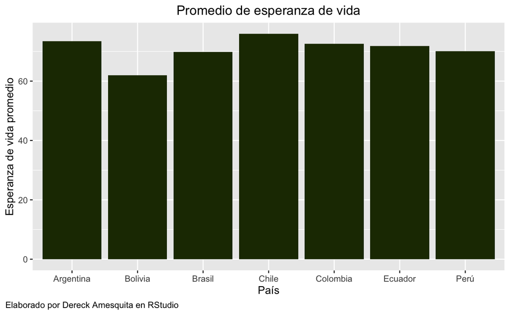

```r
grafico5 = ggplot(esperanza, aes(x=country, y=promvida)) +
  geom_col(stat="identity", fill='#213402')  +
  labs(x='País',y="Esperanza de vida promedio", title = 'Promedio de esperanza de vida')
grafico5+ubi+tit
```

# Agradecimiento

Este documento fue realizado en parte por la inspiración al leer un Rmarkdown publicado por **Ramfis Felix Tatis (Economista)**. Link de la versión PDF(t.ly/z_Cu), también aprovecho para agradecerle por la ayuda brindada para usar WDIsearch y encontrar el código de los indicadores.

## Enlaces importantes

- https://data.worldbank.org/indicator
- https://datahelpdesk.worldbank.org/knowledgebase/articles/201175-how-does-the-world-bank-code-its-indicators
- https://cran.r-project.org/web/packages/WDI/WDI.pdf
- https://wits.worldbank.org/wits/wits/witshelp/content/codes/country_codes.htm

## Aclaraciones

R es un software de código abierto, al mismo tiempo este RMarkdown puede ser usado de forma libre.